# Day_4-after-lecture slides

## Error handling

**Two paths** for error handling:

1. Check conditions before performing a task

   ```
   if x_can_be_done:
       do_this_with_x
   else:
       error_handling
   ```

2. Perform the task and deal with errors afterwards

   ```
    try:
       do_whatever_with_x
    except <ErrorType>:
       error_handling
   ```

**try and except:** Check and report errors

**Reason for catching errors:** Check if I can recover from this error

**Keep in mind:** It is good to specify the error, e.g.`except ValueError:`

### Try and except basic example

```python
try:
    int("five")
except ValueError:
    print("I do not care")
```

### Your own message + Python's message

```python
try:
    int("five")
except ValueError as err:
    print("Error: try again")
    print("python error: ", err)
```

### Catching a Recoverable Error

**Scenario:** I am perfect

Input:

- My code is perfect
- The data I use is not perfect (e.g. some entries are invalid or missing)

Output:

- The code will throw an error and stop, making it impossible to process the remaining data

```python
with open('../files/bank_statement_error.txt', 'r', encoding = 'utf-8') as bank_file:
    content = bank_file.read()
    print(content)
```

```python
with open("../files/bank_statement_error.txt", "r", encoding = "utf-8") as fh:

    total = 0

    for line in fh:
        expenses = line.strip().split()
        store = expenses[0]
        try:
            price = float(expenses[1])
        except ValueError:
            print("Wrong input: ", line)
            continue
        if store == 'ICA':
            total = total + price

print('Total amount spent on ICA is: '+str(total))
```

```python
print(f"File closed after error? {fh.closed}")
```

### Raise your own error

**Scenario:** Validating a variable

- At some point in my code, I want to stop execution if a variable is not an integer
- How can I interrupt the execution and raise an error?

```python
# Accept only integers
my_number=3.2

if type(my_number) is not int:
    raise  TypeError("Wrong type")
    #print("Oooooohhhhh NOOOOOOOO")

print("more code follows")
```

## User input

The code asks the user for input

- `input()`

```python
give_input = input("Give a number: ")

print(f'You pressed the number {give_input}')
```

### Type of input

```python
number_in=input("Give me a number: ")

type(number_in)
```

The type of the input is **ALWAYS** string

#### Ensure correct type of input (exercise)

We want a script which asks the user to give an integer number. If the input of the user is not integer then inform about that and ask again about an integer number

- Think about it and we will do it together
- Hint: inputs have string type

```python
number=None

while number is None:
    user_input=input("Give a integer number:")
    try:
        number = int(user_input)
    except ValueError:
        print("Not integer, try again !!!")

print("You have typed: ", number)
```

## Summary

### Exercise 2 (~20-30 minutes)

- Go to Canvas, `Modules -> Day 4 -> Exercise 2 - day 4`

## Lunch

# Pandas!!!

[figure not shown]

## Pandas

- Library for working with tabular data
- Data analysis:
  - filter
  - transform
  - aggregate
  - plot
- Main hero: the `DataFrame` type

### Built-in vs library tools - 1

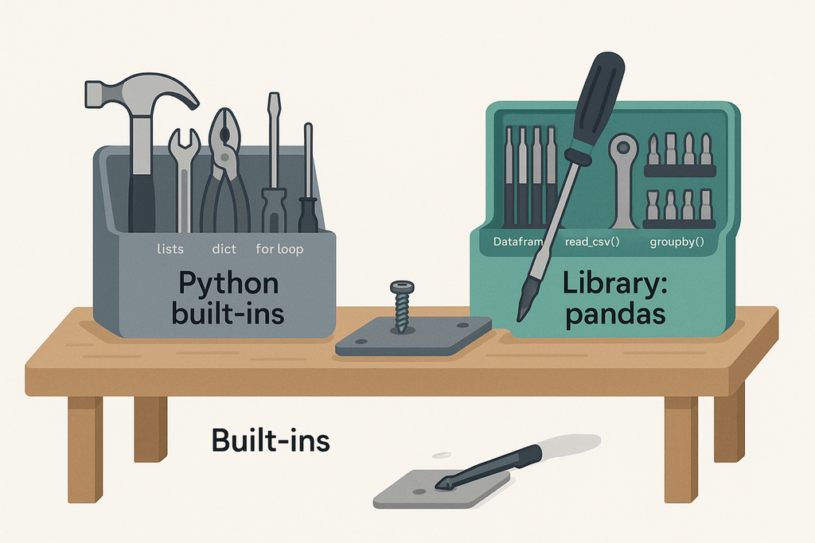

### Built-in vs library tools - 2

Task of the script:

- Load movies data from a file
- Calculate the average rating of all movies
- Filter the great movies: Rating >= 8.5
- Display them sorted by Rating (highest first), showing Title, Year, and Rating

#### Built-in solution

```python
# 1. LOAD DATA
movies = []
for line in open('../downloads/250.imdb', encoding='utf-8'):
    if line.startswith('#'):  # skip the header line
        continue
    fields = line.strip().split('|')
    rating = float(fields[1])
    year = int(fields[2])
    title = fields[6]
    movies.append([title, year, rating])

print(f"Loaded {len(movies)} movies")

# 2. AVERAGE RATING
total = 0
for movie in movies:
    total = total + movie[2]

average = total / len(movies)
print(f"\nAverage Rating: {average:.2f}")

# 3. FILTER Rating >= 8.5
top_movies = []
for movie in movies:
    if movie[2] >= 8.5:
        top_movies.append(movie)

# 4. SORT by Rating, highest first
def get_rating(movie):
    return movie[2]

top_movies.sort(key=get_rating, reverse=True)

print(f"\nGreat Movies (Rating >= 8.5): {len(top_movies)} found\n")
print(f"{'Title':<52} {'Year':>5} {'Rating':>7}")
print("─" * 66)
for movie in top_movies:
    print(f"{movie[0]:<52} {movie[1]:>5} {movie[2]:>7.1f}")
```

#### Library (pandas) solution

```python
import pandas as pd

# 1. LOAD DATA
df = pd.read_csv('../downloads/250.imdb', sep='|')

# Strip spaces from ALL column names at once
df.columns = df.columns.str.strip()

# Rename '# Votes' to 'Votes'
df = df.rename(columns={'# Votes': 'Votes'})

print(f"Loaded {len(df)} movies")

# 2. AVERAGE RATING
print(f"\nAverage Rating: {df['Rating'].mean():.2f}")

# 3. & 4. FILTER + SORT
top_movies = (
    df[df['Rating'] >= 8.5]
    .sort_values('Rating', ascending=False)
)

print(f"\nGreat Movies (Rating >= 8.5): {len(top_movies)} found")
top_movies[['Title', 'Year', 'Rating']]
```

### Built-in vs library tools - 3

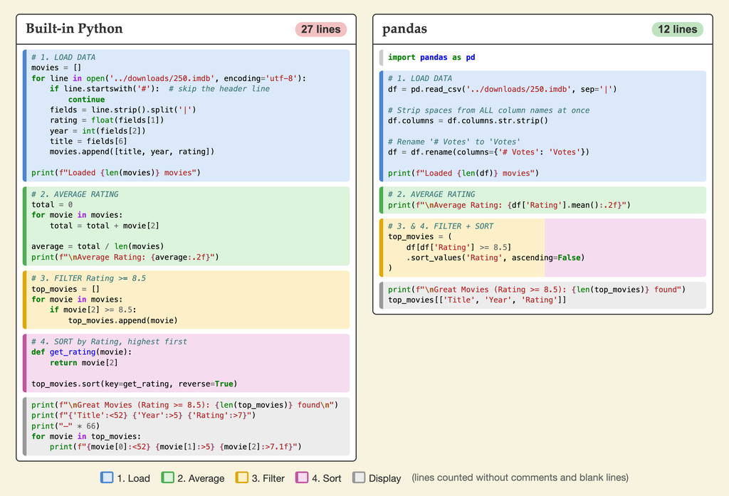

#### Benefits of shorter code

- Easier to read: you see **what** is done, not **how**
- Fewer lines, fewer places for bugs
- Easier to modify it: to sort by year, change `'Rating'` to `'Year'`

## Pandas DataFrame

Pandas Dataframe is a **2D data structure**. In other words, is a table with rows and columns.

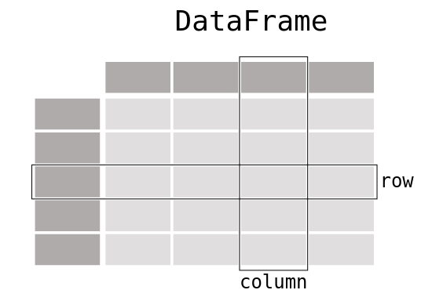

### Creating a small DataFrame

```python
import pandas as pd
data = {
    'age': [1,2,3,4],
    'circumference': [2,3,5,10],
    'height': [30, 35, 40, 50]
}

df=pd.DataFrame(data)
df
```

```python
# Locate row
df.loc[1]
```

```python
# add name index
row_index = ["tree1", "tree2", "tree3", "tree4"]
df.index = row_index
df
```

```python
# Locate row
df.loc['tree2']
```

```python
# drop index
df = df.reset_index(drop=True)
df
```

### Pandas can import data from many formats

- `pd.read_table`: tab separated values `.tsv`
- `pd.read_csv`: comma separated values `.csv`
- `pd.read_excel`: Excel spreadsheets `.xlsx`

### DataFrame can export data to many formats

- `df.to_csv(sep='\t')`: tab separated values `.tsv`
- `df.to_csv()`: comma separated values `.csv`
- `df.to_excel()`: Excel spreadsheets `.xlsx`

[figure not shown]

### Orange tree data

```python
df = pd.read_table('../downloads/Orange_1.tsv')
df
```

### Read larger file

```python
df_big = pd.read_csv('../downloads/Orange_1_big.csv')
df_big
```

Do not panic

```python
pd.options.display.max_rows
```

### Overview of your data, basic statistics

```python
df
```

```python
df.shape
```

```python
df.describe()
```

```python
df.max()
```

```python
df_big.head(10)
```

```python
df_big.tail(10)
```

```python
df_big.info()
```

### Selecting columns, rows and cells from a dataframe

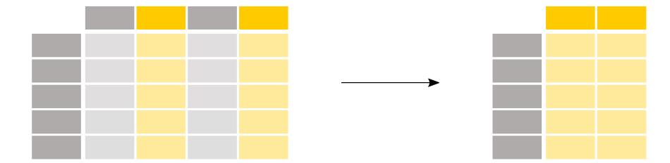

#### Selecting one column

```
dataframe.columnname
dataframe['columnname']
```

```python
df
```

```python
df.age
```

```python
df['age']
```

`df.age` only works when the column name has no spaces and is not also the name of a method.

For example, a column called *count* returns the `.count()` method instead of the data.

So the **advice** is: `df['age']` always works, so prefer it.

#### Unique values of a column

```python
df['age'].unique()
```

#### How many of each?

```python
df['age'].value_counts()
```

- `unique()` gives the different values and `value_counts()` counts how often each one appears.
- Bioinformatics examples: variants per chromosome, reads per sample, genes per biotype.

Be careful with the headers of the column

```python
import pandas as pd
data = {
    'age ': [1,2,3,4],
    'circumference': [2,3,5,10],
    'height': [30, 35, 40, 50]
}
df_test = pd.DataFrame(data)
df_test
```

```python
df_test.age
```

```python
df_test['age ']
```

Strip the spaces

```python
df_test.columns = df_test.columns.str.strip()

df_test.age
```

#### Selecting multiple columns

```python
df
```

```python
df[['age','height']]
```

#### Selecting rows from a dataframe

```python
df
```

```python
df.loc[0] # select the first row
```

```python
df.loc[1:3] # select from row 2 to 4
```

```python
df.loc[[1, 3]] # select row 2 and 4
```

**REMINDER:**

- `.loc` uses the index labels, not the position of the row
- when range is used in `.loc` the *stop* part is included

#### Selecting cells from a dataframe

```python
df
```

```python
# Single cell
df.loc[0, 'age']

# One row, multiple columns
df.loc[1,['age','height']]
# Multiple rows, one column
df.loc[[1,3],'age']
# Multiple rows and columns
```

#### Run statistics on specific rows, columns, cells

```python
df[['age', 'circumference']].describe()
```

```python
df['age'].std()
```

```python
df.loc[0].describe()
```

```python
df.loc[0, 'age'] - df['age'].mean()
```

### Selecting data from a dataframe by position

```
dataframe.iloc[row_position]
dataframe.iloc[row_position, column_position]
dataframe.iloc[start:stop]
```

**Note:** the *stop* part in the `.iloc` is not included (different from `.loc`)

Further reading from pandas documentation: https://pandas.pydata.org/docs/reference/api/pandas.DataFrame.iloc.html

```python
df
```

```python
# Show the first column
df.iloc[:,0]
# Show the second row
df.iloc[1,:]
# Show the cell of the second row and the first column
df.iloc[1,0]
```

### Creating new column derived from existing column

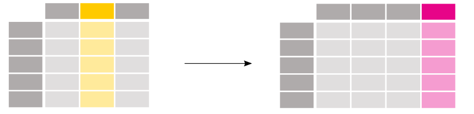

```python
import math
df['radius'] = df['circumference'] / (2.0 * math.pi)
df
```

### Quiz time

Go to Canvas, `Modules -> Day 4 -> PyQuiz 4.1`

~5 min

### Pandas concatenate

[figure not shown]

```python
df1 = pd.DataFrame({
    'age': [1,2,3,4],
    'circumference': [2,3,5,10],
    'height': [30, 35, 40, 50]
})

df1
```

```python
df2 = pd.DataFrame({
    'name': ['palm', 'ada', 'ek', 'olive'],
    'price': [1423, 2000, 102, 30]
})

df2
```

```python
df_con = pd.concat([df1,df2])
df_con
```

```python
# index is not reset and it will cause some problems
df_con.loc[0]
```

#### Reset index in concatenated dataframe

```python
df_con=df_con.reset_index(drop=True)
df_con
```

#### Control the concatenation axis:

- axis=0 (default): rows concatenation
- axis=1: columns concatenation

```python
pd.concat([df2, df1], axis=0).reset_index(drop=True)
```

```python
pd.concat([df2, df1], axis=1)
```

### Selecting/filtering the dataframe by condition

e.g.

- Only trees with age larger than 100
- Only tree with circumference shorter than 20

```python
df = pd.read_table('../downloads/Orange.tsv')
df
```

#### Selecting with condition

`dataframe[condition]`

```python
df[df['Tree'] == 1]
```

```python
df[df['age'] > 500]
```

#### Filter with multiple conditions

`dataframe[(condition 1) & (condition 2)]`

`dataframe[(condition 1) | (condition 2)]`

```python
df[(df['age'] > 100) & (df['age'] <= 250)]
```

```python
df[(df['age'] > 500) & (df['circumference'] < 100) ]
```

```python
df[(df['Tree'] == 1) | (df['Tree'] == 3)]
```

- `&` means "and": both conditions must be true
- `|` means "or": at least one condition must be true
- Put each condition in brackets ( )
- Do not use the Python words **and**/**or** here

#### Small exercise 1

- Find the maximal circumference and then filter the dataframe by it

```python
max_circ = df['circumference'].max()
df[df['circumference'] == max_circ]
```

#### Statistics per group

**Question:** what is the maximum circumference of each tree?

```python
df.groupby('Tree')['circumference'].max()
```

- `groupby('Tree')`: split the table into one group per tree
- `['circumference']`: choose the column
- `.max()`: calculate the maximum for each group; the results are combined into one table

**Bioinformatics examples:** the mean expression per gene, the number of variants per sample.

#### Saving your results to a file

```python
# create table
old_trees = df[df['age'] > 1000]
old_trees
old_trees.to_csv('old.csv',index=False)
```

```python
# read table
pd.read_csv('old.csv')
```

### Quiz time

Go to Canvas, `Modules -> Day 4 -> PyQuiz 4.2`

### Plotting

- pandas can plot your data directly
- One pattern for all plots:

  ```
  df.plot(x='column', y='column', kind='...')
  ```

- More information: https://pandas.pydata.org/docs/reference/api/pandas.DataFrame.plot.html

#### Which plot for which question?

| `kind` | Use it for | Bioinformatics example |
| --- | --- | --- |
| `line` | change over time or in order | growth, time course |
| `scatter` | relationship between two numbers | expression of gene A vs gene B |
| `hist` | distribution of one variable | read lengths, quality scores |
| `box` | comparing distributions between groups | expression per condition |
| `bar` | comparing categories | number of variants per chromosome |

#### The data we will plot

```python
import pandas as pd

df = pd.read_table('../downloads/Orange.tsv')
df_big = pd.read_csv('../downloads/Orange_1_big.csv')
```

#### Line plot

```python
tree1 = df[df['Tree'] == 1]
tree1
# Simplest plot: df.columnname.plot() - default=line
#tree1.age.plot()

# Nicer plot: set x and y axis, kind, title, labels
tree1.plot(x='age',y='circumference',kind='line', title='growth ...',
        xlabel='Age (days)', ylabel='Circumference (mm)')
```

#### Scatter plot

```python
df.plot(kind='scatter', x='age', y='circumference',
        title='Age vs circumference',
        xlabel='Age (days)', ylabel='Circumference (mm)');
```

#### Histogram

```python
df_big.plot(kind='hist', y='height', bins=2,
            title='Distribution of tree height', xlabel='Height')
```

#### Box plot

```python
df.boxplot(column='circumference', by='Tree')
```

#### Bar plot

```python
df.groupby('Tree')['circumference'].max().plot(kind='bar',
        title='Maximum circumference per tree',
        xlabel='Tree', ylabel='Circumference (mm)')
```

#### Size and font

```python
# figsize and fontsize
df.plot(kind='scatter', x='age', y='circumference',
        title='Age vs circumference',
        xlabel='Age (days)', ylabel='Circumference (mm)',
        fontsize=16, figsize=(12, 8))
```

#### Build your plot step by step

```python
a =df.plot(kind='scatter', x='age', y='circumference',
        figsize=(12, 8), fontsize=16)
a.set_title('whatever', fontsize=20)
a.set_xlabel('age', fontsize=20)
a.set_ylabel('circumference', fontsize=20)
```

#### Saving a plot

```python
ax = df.plot(kind='scatter', x='age', y='circumference',
             title='Age vs circumference',
             xlabel='Age (days)', ylabel='Circumference (mm)')

ax.figure.savefig('orange_scatter.png', dpi=300)
```

### Exercise 3 (~30 minutes)

- Go to Canvas, `Modules -> Day 4 -> Exercise 3 - day 4`

**INFO**: Re-download `downloads.zip` from the pre-course material if you do not have the `hypoxia_rnaseq.xlsx` in the downloads folder